# Labo 7

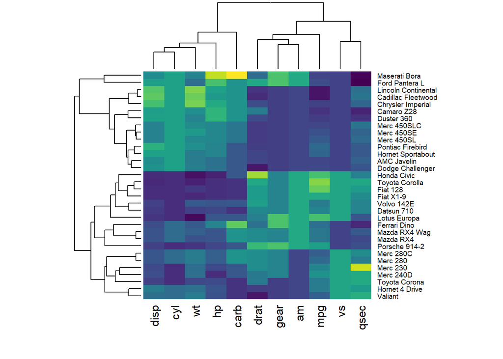

```r
colores <- viridis(256)
heatmap(x = datos, scale = "none", col = colores,
        distfun = function(x){dist(x, method = "euclidean")},
        hclustfun = function(x){hclust(x, method = "average")},
        cexRow = 0.7)
```

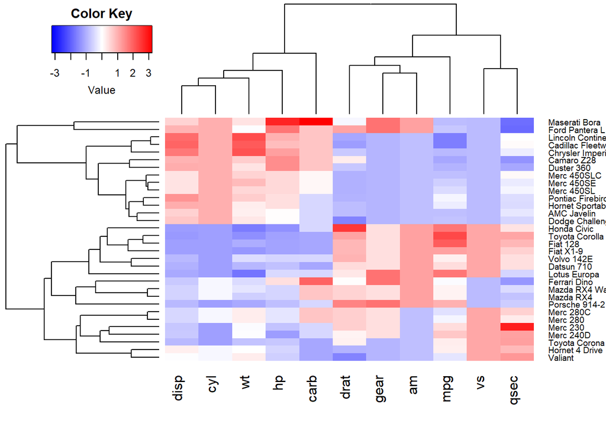

```r
library(gplots)
heatmap.2(x = datos, scale = "none", col = bluered(256),
          distfun = function(x){dist(x, method = "euclidean")},
          hclustfun = function(x){hclust(x, method = "average")},
          density.info = "none",
          trace = "none", cexRow = 0.7)
```

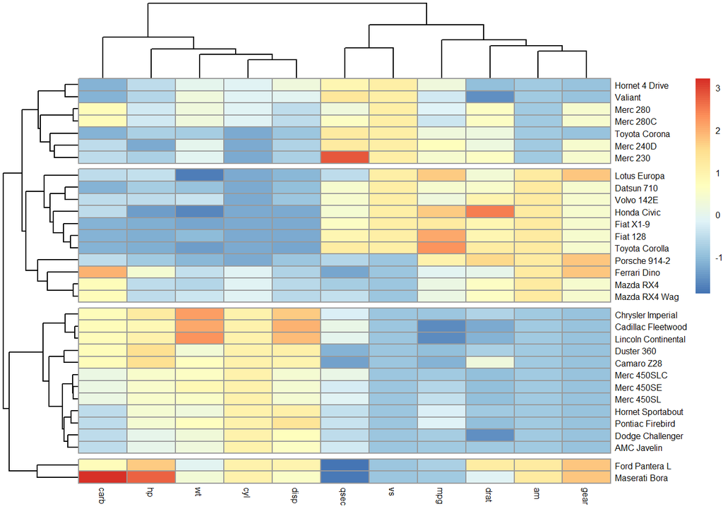

```r
pheatmap(mat = datos, scale = "none", clustering_distance_rows = "euclidean",
         clustering_distance_cols = "euclidean", clustering_method = "average",
         cutree_rows = 4, fontsize = 6)
```

```r
# Al tratarse de html no puede visualizarse en word o PDF
d3heatmap(x = datos, k_row = 4, k_col = 2, scale = "none",
          distfun = function(x){dist(x, method = "euclidean")},
          hclustfun = function(x){hclust(x, method = "average")})
```

[interactive chart not shown]

## Perfiles o segmentaciones

Acá se debe de describir los clusters como tal. Es realizar estadísticas descriptivas para entender su composición.

Un ejemplo con una tabla: https://rpubs.com/vermaph/395036

```r
library("ggplot2")  # For visualizations
library("cluster")  # For calculating the Gower Distance
library("Rtsne")    # For visualizing the clustering in 2-D
library("RODBC")    # For connecting SQL RFM view with R
library("dplyr")
library("kableExtra")
#dbconnection <- odbcDriverConnect("Driver=ODBC Driver 11 for SQL Server;Server=SCOTT\\SQLEXPRESS; Database=SUPERMARKET;Uid=; Pwd=; trusted_connection=yes")
#Customer_Data <- sqlQuery(dbconnection,paste("select * from RFM;"))
#odbcClose(dbconnection)

## Calculate Gower Distance
#gower_dist <- daisy(Customer_Data[,-1],metric = "gower", type = list(logratio = c(8:13)))
# Log transformation for positively skewed variables: FAMILY_TOT_SALES, FAMILY_TOT_VISITS


## Calculate optimal number of clusters
#sil_width <- c(NA)
#for(i in 2:20){
#  pam_fit<-pam(gower_dist, diss = TRUE,k = i)  # PAM: Partitioning Around Medoids
#  sil_width[i]<-pam_fit$silinfo$avg.width
#}
#tab<-data.frame(x=1:20,sil_width=sil_width)

#pam_fit<-pam(gower_dist, diss=TRUE, k = 7)
#Customer_Data<-cbind(Customer_Data, Group = pam_fit$clustering)

#tsne_obj <- Rtsne(gower_dist, is_distance = TRUE)
#tsne_data <- tsne_obj$Y %>%
#  data.frame() %>%
#  setNames(c("X", "Y")) %>%
#  mutate(cluster = factor(pam_fit$clustering),
#         name = Customer_Data$H_KEY)

#ggplot(aes(x = X, y = Y), data = tsne_data) + geom_point(aes(color = cluster)) + ggtitle("Customer Segments") + theme(plot.title = element_text(hjust = 0.5))

#Customer_Data %>%
#  mutate(Group = as.factor(Group)) %>%
#  group_by(Group) %>%
#  summarize(Avg_sales = round(mean(ANNUAL_SALES),2),
#            Avg_visits = round(mean(ANNUAL_VISITS),2),
#            Avg_basket_value = round(mean(ANNUAL_BASKET_VALUE),2),
#            Avg_Recency = round(mean(RECENCY),2),
#            Avg_Frequency = round(mean(FREQUENCY),2),
#            Avg_Monetary = round(mean(MONETARY),2),
#            Count_of_Members = n()
#            ) %>%
#  arrange(Group) %>%
#  mutate_if(is.numeric, function(x) {
#    cell_spec(x, bold = T,
#              color = spec_color(x, end = 0.9),
#              font_size = spec_font_size(x))
#  }) %>%
#  kable(escape = F, align = "c") %>%
#  kable_styling(c("striped", "condensed"), full_width = F)
```

## Otros puntos

### Comparación de dendogramas

Dados los muchos parámetros que se tienen que determinar a lo largo del proceso de hierarchical clustering, es frecuente que el analista genere varios dendrogramas para compararlos y escoger finalmente uno de ellos. Existen varias formas de estudiar las diferencias entre dendrogramas, dos de las más utilizadas son: la comparación visual y el cálculo de correlación entre dendrogramas. Ambos métodos pueden aplicarse con las funciones tanglegram() y cor.dendlist() del paquete dendextend. Se emplea el set de datos USArrests con el objetivo de generar dendrogramas que agrupen los diferentes estados por su similitud en el porcentaje de asesinatos, asaltos, secuestros y proporción de población rural. Se comparan los resultados obtenidos empleando linkage average y ward.D2.

```r
# Para facilitar la interpretación se simplifican los dendrogramas empleando
# únicamente 10 estados

set.seed(123)
datos <- USArrests[sample(1:50, 10), ]

# Cálculo matriz de distancias
mat_dist <- dist(x = datos, method = "euclidean")

# Cálculo de hierarchical clustering
hc_average <- hclust(d = mat_dist, method = "average")
hc_ward    <- hclust(d = mat_dist, method = "ward.D2")

# Las funciones del paquete dendextend trabajan con objetos de tipo dendrograma,
# para obtenerlos se emplea la función as.dendogram()
dend_1 <- as.dendrogram(hc_average)
dend_2 <- as.dendrogram(hc_ward)
```

#### Comparación visual

La función tanglegram() representa dos dendrogramas a la vez, enfrentados uno al otro, y conecta las hojas terminales con líneas. Los nodos que aparecen solo en uno de los dendrogramas, es decir, que están formados por una combinación de observaciones que no se da en el otro, aparecen destacados con líneas discontinuas.

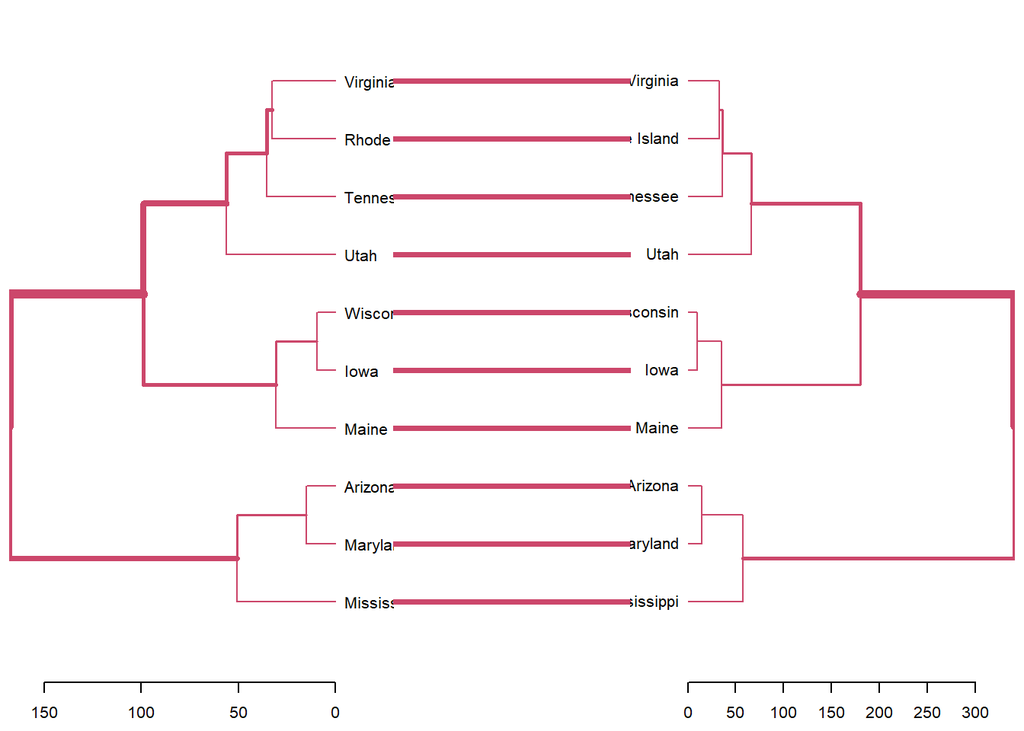

```r
tanglegram(dend1 = dend_1, dend2 = dend_2, highlight_distinct_edges = TRUE,
           common_subtrees_color_branches = TRUE)
```

#### Comparación por correalación

Con la función cor.dendlist() se puede calcular la matriz de correlación entre dendrogramas basada en las distancias de Cophenetic o Baker.

```r
# Se almacenan los dendrogramas a comparar en una lista
list_dendrogramas <- dendlist(dend_1, dend_2)
cor.dendlist(dend = list_dendrogramas, method = "cophenetic")
```

```
##           [,1]      [,2]
## [1,] 1.0000000 0.9977162
## [2,] 0.9977162 1.0000000
```

```r
# Se pueden obtener comparaciones múltiples incluyendo más de dos dendrogramas en
# la lista pasada como argumento
dend_1 <- datos %>% dist(method = "euclidean") %>% hclust(method = "average") %>%
          as.dendrogram()
dend_2 <- datos %>% dist(method = "euclidean") %>% hclust(method = "ward.D2") %>%
          as.dendrogram()
dend_3 <- datos %>% dist(method = "euclidean") %>% hclust(method = "single") %>%
          as.dendrogram()
dend_4 <- datos %>% dist(method = "euclidean") %>% hclust(method = "complete") %>%
          as.dendrogram()
list_dendrogramas <- dendlist("average" = dend_1, "ward.D2" = dend_2,
                             "single" = dend_3, "complete" = dend_4)
cor.dendlist(dend = list_dendrogramas, method = "cophenetic") %>% round(digits= 3)
```

```
##          average ward.D2 single complete
## average    1.000   0.998  0.977    0.959
## ward.D2    0.998   1.000  0.964    0.952
## single     0.977   0.964  1.000    0.943
## complete   0.959   0.952  0.943    1.000
```

```r
# Si solo se comparan dos dendrogramas se puede emplear la función cor_cophenetic
cor_cophenetic(dend1 = dend_1, dend2 = dend_2)
```

```
## [1] 0.9977162
```

### Elección del mejor algoritmo de clustering

Decidir cuál es el método de clustering más adecuado para un determinado set de datos es un proceso complejo ya que se tienen que analizar uno a uno múltiples índices, estadísticos y parámetros (número de clusters, homogeneidad, separación, significancia…). El paquete clValid agiliza el proceso ofreciendo la posibilidad de comparar, de forma simultánea, múltiples algoritmos de clustering en una única función. Empleando el set de datos iris, se evalúan los métodos de clustering (K-means, hierarchical y PAM), empleando medidas de validación internas (conectividad, silhouette, Dunn y estabilidad), para un rango de cluster de 2 a 6.

```r
datos <- scale(iris[, -5])
comparacion <- clValid(obj = datos, nClust = 2:6,
                       clMethods = c("hierarchical", "kmeans", "pam"),
                       validation = c("stability", "internal"))
summary(comparacion)
```

```
##
## Clustering Methods:
##  hierarchical kmeans pam
##
## Cluster sizes:
##  2 3 4 5 6
##
## Validation Measures:
##                                  2       3       4       5       6
##
## hierarchical APN            0.0033  0.0370  0.0859  0.1088  0.1342
##              AD             1.4924  1.4601  1.4015  1.3269  1.2251
##              ADM            0.0161  0.1451  0.1448  0.3919  0.3176
##              FOM            0.5957  0.5809  0.5571  0.5334  0.5101
##              Connectivity   0.9762  5.5964  7.5492 18.0508 24.7306
##              Dunn           0.2674  0.1874  0.2060  0.0700  0.0762
##              Silhouette     0.5818  0.4803  0.4067  0.3746  0.3248
## kmeans       APN            0.0128  0.1034  0.1290  0.2130  0.2950
##              AD             1.5060  1.2685  1.1568  1.1269  1.0949
##              ADM            0.0555  0.2152  0.2147  0.4499  0.5147
##              FOM            0.6049  0.5206  0.4888  0.4805  0.4910
##              Connectivity   0.9762 23.8151 25.9044 40.3060 40.1385
##              Dunn           0.2674  0.0265  0.0700  0.0808  0.0808
##              Silhouette     0.5818  0.4599  0.4189  0.3455  0.3441
## pam          APN            0.0128  0.1162  0.1420  0.1655  0.1886
##              AD             1.5060  1.2721  1.1665  1.0726  1.0043
##              ADM            0.0555  0.2266  0.2500  0.2834  0.2814
##              FOM            0.6049  0.5032  0.4828  0.4789  0.4558
##              Connectivity   0.9762 23.0726 31.8067 35.7964 44.5413
##              Dunn           0.2674  0.0571  0.0566  0.0642  0.0361
##              Silhouette     0.5818  0.4566  0.4091  0.3574  0.3400
##
## Optimal Scores:
##
##              Score  Method       Clusters
## APN          0.0033 hierarchical 2
## AD           1.0043 pam          6
## ADM          0.0161 hierarchical 2
## FOM          0.4558 pam          6
## Connectivity 0.9762 hierarchical 2
## Dunn         0.2674 hierarchical 2
## Silhouette   0.5818 hierarchical 2
```

La mayoría de índices coinciden en que el mejor método es el hierarchical clustering con 2 clusters. Sin embargo, dado que se conoce la verdadera clasificación de las observaciones (Species), se sabe que realmente existen 3 grupos en la población.